# Analysis of conditions sustaining PI

## Testing a hypothesis in the original paper

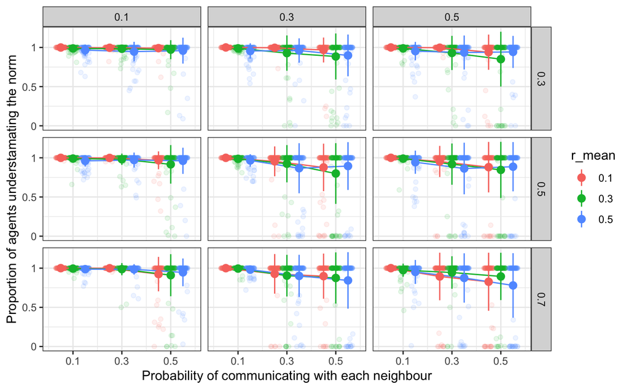

There is a general trend that increased probability of communicating with neighbours leads to fewer agents underestimating the proportion of supporters. However, the decrease may not be statistically significant since the error bars overlap to a great extent. This holds under different combinations of bounded confidence threshold, convergent parameter, and resistance to norm.

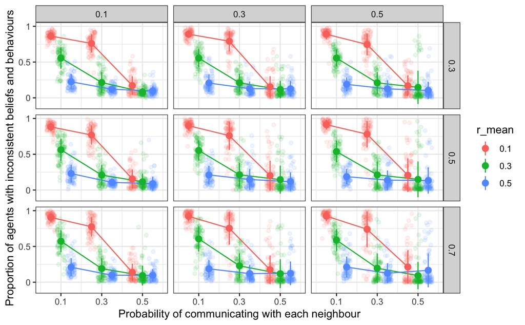

When resistance to norm is low, increased communication significantly decreases the proportion of agents with inconsistent beliefs and actions. When resistance to norm is high, the decrease tends to be small as there are few agents with such an inconsistency even though they don’t communciate much with their neighbours. This pattern is similar across different values of bounded confidence threshold and convergence parameter.

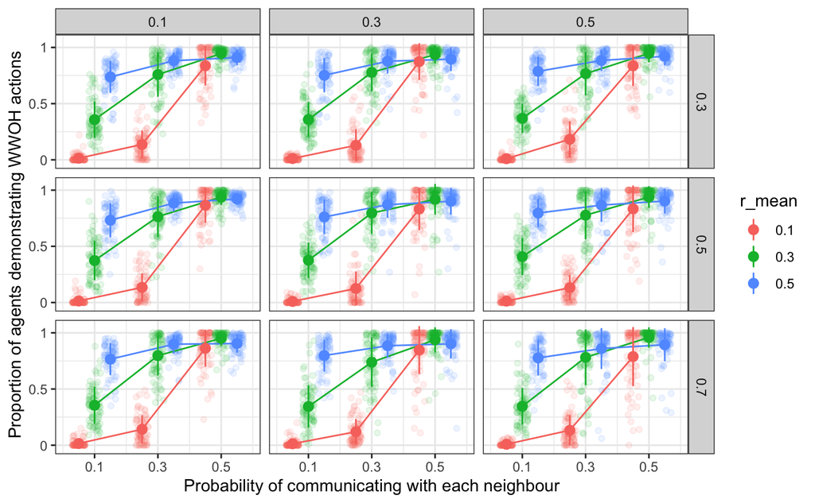

Similar (but reversed) patterns for proportion of agents demonstration WWOH actions.

For other values of `p_rewire` and `conf_mean`

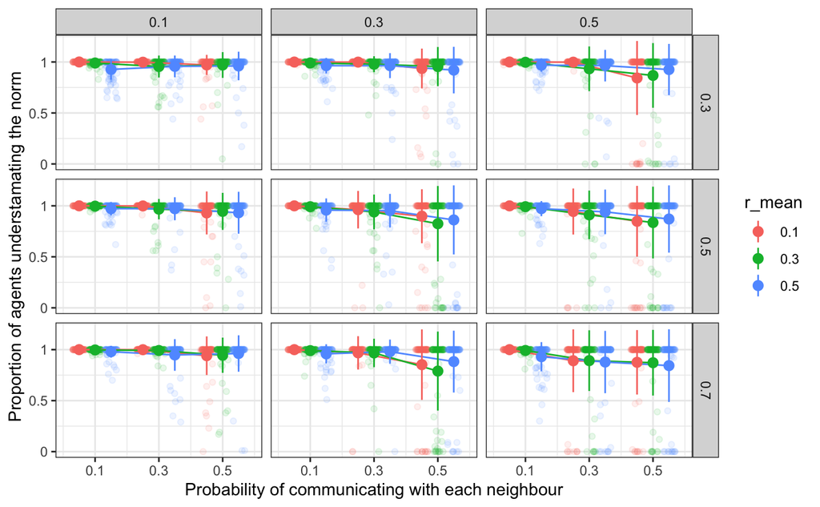

## Conditions that sustaining the PI at the original level

```r
outcome_des <-
  joint_dat %>%
  filter(intervention == "none") %>%
  group_by(p_rewire, p_com, bc_threshold_mean, alpha, conf_mean, r_mean) %>%
  summarise(across(c(p_underestimate, p_wwoh), list(mean = mean, sd = sd),
                   .names = "{.col}.{.fn}"), .groups = "keep")
```

| p_rewire | p_com | bc_threshold_mean | alpha | conf_mean | r_mean | p_underestimate.estimate | p_underestimate.statistic | p_underestimate.p.value | p_underestimate.parameter | p_underestimate.conf.low | p_underestimate.conf.high | p_underestimate.method | p_underestimate.alternative | p_wwoh.estimate | p_wwoh.statistic | p_wwoh.p.value | p_wwoh.parameter | p_wwoh.conf.low | p_wwoh.conf.high | p_wwoh.method | p_wwoh.alternative |
| --- | --- | --- | --- | --- | --- | --- | --- | --- | --- | --- | --- | --- | --- | --- | --- | --- | --- | --- | --- | --- | --- |

No parameter combinations satisfy both conditions on `p_underestimate` and `p_wwoh`

| p_rewire | p_com | bc_threshold_mean | alpha | conf_mean | r_mean | p_underestimate.mean | p_underestimate.sd | p_wwoh.mean | p_wwoh.sd | p_wwoh.estimate | p_wwoh.statistic | p_wwoh.p.value | p_wwoh.parameter | p_wwoh.conf.low | p_wwoh.conf.high | p_wwoh.method | p_wwoh.alternative |
| --- | --- | --- | --- | --- | --- | --- | --- | --- | --- | --- | --- | --- | --- | --- | --- | --- | --- |
| 0.3 | 0.3 | 0.5 | 0.1 | 0.1 | 0.1 | 0.9986667 | 0.010440738 | 0.06386667 | 0.06630995 | 0.06386667 | -96.14096 | 1.843983e-79 | 74 | 0.04861013 | 0.07912320 | One Sample t-test | two.sided |
| 0.3 | 0.3 | 0.5 | 0.3 | 0.1 | 0.1 | 0.9621333 | 0.183879318 | 0.04880000 | 0.05870126 | 0.04880000 | -110.82527 | 5.356807e-84 | 74 | 0.03529407 | 0.06230593 | One Sample t-test | two.sided |
| 0.3 | 0.3 | 0.7 | 0.1 | 0.1 | 0.1 | 0.9994667 | 0.004618802 | 0.05506667 | 0.06230642 | 0.05506667 | -103.54169 | 7.940070e-82 | 74 | 0.04073126 | 0.06940207 | One Sample t-test | two.sided |
| 0.3 | 0.3 | 0.7 | 0.3 | 0.1 | 0.1 | 0.9685333 | 0.163373998 | 0.06066667 | 0.07056401 | 0.06066667 | -90.73768 | 1.286040e-77 | 74 | 0.04443136 | 0.07690197 | One Sample t-test | two.sided |
| 0.3 | 0.3 | 0.7 | 0.5 | 0.1 | 0.1 | 0.8910667 | 0.307446209 | 0.06653333 | 0.07883430 | 0.06653333 | -80.57416 | 7.748462e-74 | 74 | 0.04839521 | 0.08467146 | One Sample t-test | two.sided |
| 0.5 | 0.1 | 0.3 | 0.1 | 0.5 | 0.1 | 0.9976000 | 0.008517073 | 0.06173333 | 0.07121292 | 0.06173333 | -89.78114 | 2.797804e-77 | 74 | 0.04534873 | 0.07811794 | One Sample t-test | two.sided |
| 0.5 | 0.1 | 0.3 | 0.3 | 0.5 | 0.1 | 0.9993333 | 0.002511236 | 0.04840000 | 0.06434787 | 0.04840000 | -101.15404 | 4.409633e-81 | 74 | 0.03359490 | 0.06320510 | One Sample t-test | two.sided |
| 0.5 | 0.1 | 0.3 | 0.5 | 0.5 | 0.1 | 0.9992000 | 0.004274374 | 0.06133333 | 0.09228823 | 0.06133333 | -69.31589 | 4.607150e-69 | 74 | 0.04009974 | 0.08256693 | One Sample t-test | two.sided |
| 0.5 | 0.1 | 0.5 | 0.1 | 0.5 | 0.1 | 0.9994667 | 0.002796394 | 0.05333333 | 0.07256560 | 0.05333333 | -89.11004 | 4.850266e-77 | 74 | 0.03663751 | 0.07002916 | One Sample t-test | two.sided |
| 0.5 | 0.1 | 0.5 | 0.3 | 0.5 | 0.1 | 1.0000000 | 0.000000000 | 0.05626667 | 0.08678606 | 0.05626667 | -74.21606 | 3.154704e-71 | 74 | 0.03629901 | 0.07623433 | One Sample t-test | two.sided |

[output cut: 22 more lines]

| p_rewire | p_com | bc_threshold_mean | alpha | conf_mean | r_mean | p_underestimate.mean | p_underestimate.sd | p_wwoh.mean | p_wwoh.sd | p_underestimate.estimate | p_underestimate.statistic | p_underestimate.p.value | p_underestimate.parameter | p_underestimate.conf.low | p_underestimate.conf.high | p_underestimate.method | p_underestimate.alternative |
| --- | --- | --- | --- | --- | --- | --- | --- | --- | --- | --- | --- | --- | --- | --- | --- | --- | --- |
| 0.3 | 0.3 | 0.7 | 0.5 | 0.3 | 0.3 | 0.8696000 | 0.3043977 | 0.7120000 | 0.20839152 | 0.8696000 | 1.980152038 | 0.05140479 | 74 | 0.7995645 | 0.9396355 | One Sample t-test | two.sided |
| 0.3 | 0.3 | 0.7 | 0.5 | 0.5 | 0.3 | 0.8626667 | 0.3145238 | 0.8296000 | 0.15323044 | 0.8626667 | 1.725494989 | 0.08861219 | 74 | 0.7903013 | 0.9350320 | One Sample t-test | two.sided |
| 0.3 | 0.3 | 0.7 | 0.5 | 0.5 | 0.5 | 0.8660000 | 0.3287733 | 0.8788000 | 0.13857343 | 0.8660000 | 1.738513263 | 0.08627952 | 74 | 0.7903561 | 0.9416439 | One Sample t-test | two.sided |
| 0.3 | 0.5 | 0.3 | 0.5 | 0.1 | 0.1 | 0.8430667 | 0.3626739 | 0.6834667 | 0.21927086 | 0.8430667 | 1.028384646 | 0.30711867 | 74 | 0.7596230 | 0.9265104 | One Sample t-test | two.sided |
| 0.3 | 0.5 | 0.3 | 0.5 | 0.1 | 0.3 | 0.8681333 | 0.3171226 | 0.9164000 | 0.10574881 | 0.8681333 | 1.860643136 | 0.06676747 | 74 | 0.7951701 | 0.9410966 | One Sample t-test | two.sided |
| 0.3 | 0.5 | 0.3 | 0.5 | 0.3 | 0.3 | 0.8490667 | 0.3495641 | 0.9008000 | 0.12776414 | 0.8490667 | 1.215599064 | 0.22800159 | 74 | 0.7686393 | 0.9294941 | One Sample t-test | two.sided |
| 0.3 | 0.5 | 0.5 | 0.3 | 0.1 | 0.3 | 0.8245333 | 0.3699426 | 0.8954667 | 0.11635562 | 0.8245333 | 0.574318507 | 0.56749406 | 74 | 0.7394173 | 0.9096494 | One Sample t-test | two.sided |
| 0.3 | 0.5 | 0.5 | 0.3 | 0.1 | 0.5 | 0.8617333 | 0.3385916 | 0.9029333 | 0.09427925 | 0.8617333 | 1.578971228 | 0.11860808 | 74 | 0.7838305 | 0.9396362 | One Sample t-test | two.sided |
| 0.3 | 0.5 | 0.5 | 0.5 | 0.1 | 0.1 | 0.8482667 | 0.3474361 | 0.6980000 | 0.26918295 | 0.8482667 | 1.203103638 | 0.23277127 | 74 | 0.7683289 | 0.9282044 | One Sample t-test | two.sided |
| 0.3 | 0.5 | 0.5 | 0.5 | 0.1 | 0.3 | 0.8360000 | 0.3515525 | 0.8868000 | 0.15546061 | 0.8360000 | 0.886835135 | 0.37804082 | 74 | 0.7551151 | 0.9168849 | One Sample t-test | two.sided |

[output cut: 87 more lines]

Parameter combinations that satisfy conditions on `p_wwoh` look fine, while those satisfying conditions on `p_underestimate` obviously don’t satisfying the condition on `p_wwoh`. We will choose the former for later analysis.